# Homework 1: Linear Regression

Chamroeun Chhay

There are six questions (30 total points) in this assignment. The minimum increment is 1 point. Please type in your answers directly in the R Markdown file. After completion, **successfully** knitr it as an html file. Submit **both** the html file and the R Markdown file via Canvas. Please name the R Markdown file in the following format: LastName_FirstName_HW1.Rmd, e.g. Zhao_Zifeng_HW1.Rmd.

## Used Car Dataset [9 points]

The used car dataset is the one we analyzed in class. Let’s read in the data stored in `UsedCar.csv`.

```r
usedcar <- read.csv('~/Downloads/UsedCar.csv')
```

### **Q1 [2 points]**

Since the dependent variable `Price` is severely right-skewed, create a log-transformation of `Price` and store it as a new variable named `Log_price` within the data.frame `total_data`.

```r
usedcar$log_price <- log(usedcar$Price + 1)
```

### **Q2 [7 points]**

Fit a linear regression model of Log_price w.r.t. two predictors Age and Mileage, name it `lm_short`.

```r
lm_short <- lm(log_price ~ Age + Mileage, data = usedcar)
```

**Q2(a) [2 points]** What is the $R^2$ of `lm_short`? What are the (in-sample) MAE and RMSE of `lm_short` at the *original scale*?

```r
summary(lm_short)
```

```
##
## Call:
## lm(formula = log_price ~ Age + Mileage, data = usedcar)
##
## Residuals:
##      Min       1Q   Median       3Q      Max
## -0.84324 -0.08037  0.00043  0.07970  0.49794
##
## Coefficients:
##               Estimate Std. Error t value Pr(>|t|)
## (Intercept)  1.004e+01  1.101e-02  911.69   <2e-16 ***
## Age         -1.217e-02  2.151e-04  -56.58   <2e-16 ***
## Mileage     -1.757e-06  1.067e-07  -16.48   <2e-16 ***
## ---
## Signif. codes:  0 '***' 0.001 '**' 0.01 '*' 0.05 '.' 0.1 ' ' 1
##
## Residual standard error: 0.1307 on 1433 degrees of freedom
## Multiple R-squared:  0.8055, Adjusted R-squared:  0.8052
## F-statistic:  2967 on 2 and 1433 DF,  p-value: < 2.2e-16
```

```r
library(forecast)
original_scale <- exp(lm_short$fitted.values) - 1

accuracy(original_scale, usedcar$Price)
```

```
##                ME    RMSE    MAE      MPE     MAPE
## Test set 101.3261 1526.21 1065.2 -0.87791 9.980231
```

Answer: The $R^2$ of `lm_short` is .8055. The in-sample MAE and RMSE of `lm_short` at the *original scale* is MAE (1065.2) and RMSE (1526.21).

**Q2(b) [2 point]** What is the estimated coefficient of `lm_short` for Age and Mileage?

```r
lm_short$coefficients
```

```
##   (Intercept)           Age       Mileage
##  1.003508e+01 -1.216931e-02 -1.757371e-06
```

**Q2(c) [3 points]** How should we interpret the estimated coefficient of Age at the log-scale and the original scale of Price?

Answer: the log-scale shows that the Log Price decrease by 1.217e-02 for each unit increase in Age. For the original scale, the original price would decrease by (1.216931e-02 * 100) % or 1.22% decrease for each unit increase in Age.

## Car Seat Sales Dataset [21 points]

The car seat sales dataset contains sales of child car seats at 400 different stores and the data is stored in `Carseats.csv`. It contains 9 variables, `Sales`, `CompPrice`, `Income`, `Advertising`, `Population`, `Price`, `ShelveLoc`, `Age` and `Urban`. We would like to build a linear regression model to predict `Sales` at a planned new store. The data description is as follows.

- `Sales`: Unit sales (in thousands) at each location
- `CompPrice`: Price charged by competitor at each location
- `Income`: Community income level (in thousands of dollars)
- `Advertising`: Local advertising budget for company at each location (in thousands of dollars)
- `Population`: Population size in region (in thousands)
- `Price`: Price company charges for car seats at each site
- `ShelveLoc`: A factor with levels Bad, Good and Medium indicating the quality of the shelving location for the car seats at each site
- `Age`: Average age of the local population
- `Urban`: A factor with levels No and Yes to indicate whether the store is in an urban or rural location

### **Q4 [2 points]**

Which variable is the dependent variable? Which predictors are categorical variables?

Answer: The dependent variable is the `Sales`. The categorical variables are `ShelveLoc` and `Urban`.

### **Q5 [9 points]**

Let’s read in the data and perform visualization to get a better sense of the data.

**Q5(a) [2 points]** Correctly read in the data stored at `Carseats.csv`.

```r
carseats <- read.csv('~/Downloads/Carseats.csv')
```

**Q5(b) [2 points]** Produce a scatterplot between `Sales` and `Price`. What is the general pattern from the scatterplot?

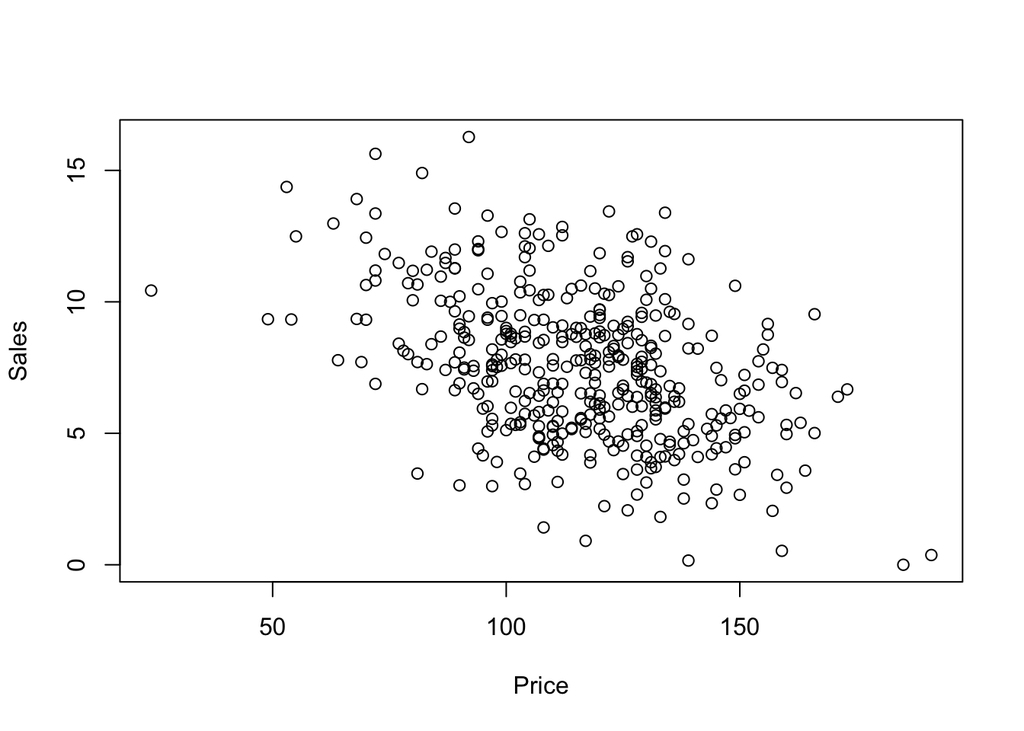

```r
plot(carseats$Price, carseats$Sales, xlab = 'Price', ylab = 'Sales')
```

Answer: There seems to be a negative relationship between `Price` and `Sales`. The scatter plot shows that as `Price` increases, `Sales` decreases.

**Q5(c) [2 points]** Produce a boxplot between `Sales` and `ShelveLoc`. What is the general pattern from the boxplot?

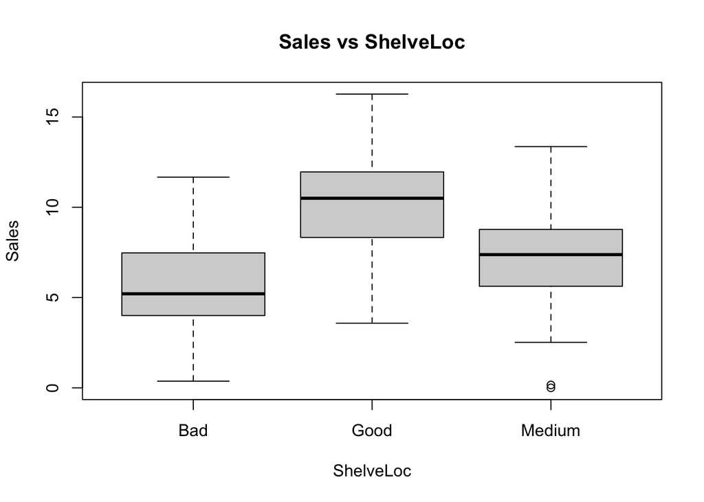

```r
boxplot(carseats$Sales ~ carseats$ShelveLoc,xlab = 'ShelveLoc', ylab = 'Sales', main = 'Sales vs ShelveLoc')
```

Answer: The boxplot shows that the better the `ShelveLoc`, the higher number of `Sales` there are.

**Q5(d) [3 points]** Produce a histogram of `Sales`. Is `Sales` severely right-skewed?

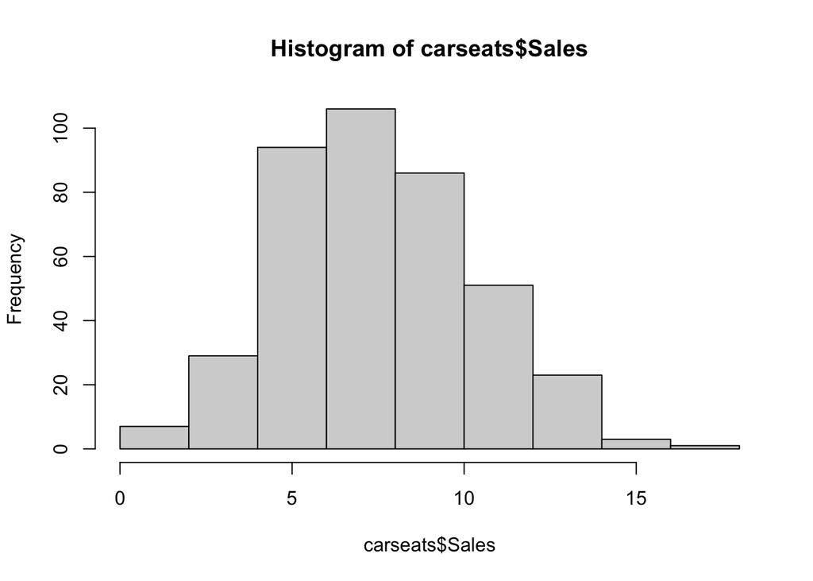

```r
hist(carseats$Sales)
```

Answer: The histogram does not show that the data is skewed in any direction. There seems to be a normal distribution in the data.

### **Q6 [10 points]**

**Q6(a) [4 points]** Fit a linear regression model of the original scale `Sales` w.r.t. all the predictors available in the dataset, name it `lm_full`. Take a look at the summary of `lm_full`.

```r
lm_full <- lm(Sales ~., data = carseats)
summary(lm_full)
```

```
##
## Call:
## lm(formula = Sales ~ ., data = carseats)
##
## Residuals:
##     Min      1Q  Median      3Q     Max
## -2.7868 -0.6988  0.0160  0.6786  3.2736
##
## Coefficients:
##                   Estimate Std. Error t value Pr(>|t|)
## (Intercept)      5.3037420  0.5263440  10.077  < 2e-16 ***
## CompPrice        0.0926753  0.0041490  22.337  < 2e-16 ***
## Income           0.0157694  0.0018400   8.570 2.44e-16 ***
## Advertising      0.1136057  0.0080241  14.158  < 2e-16 ***
## Population       0.0003255  0.0003627   0.897    0.370
## Price           -0.0954335  0.0026720 -35.716  < 2e-16 ***
## ShelveLocGood    4.8538486  0.1530955  31.705  < 2e-16 ***
## ShelveLocMedium  1.9681961  0.1259228  15.630  < 2e-16 ***
## Age             -0.0461324  0.0031829 -14.494  < 2e-16 ***
## UrbanYes         0.1268438  0.1129471   1.123    0.262
## ---
## Signif. codes:  0 '***' 0.001 '**' 0.01 '*' 0.05 '.' 0.1 ' ' 1
##
## Residual standard error: 1.02 on 390 degrees of freedom
## Multiple R-squared:  0.8726, Adjusted R-squared:  0.8697
## F-statistic: 296.9 on 9 and 390 DF,  p-value: < 2.2e-16
```

**Q6(b) [2 points]** What is the estimated coefficient of `lm_full` for CompPrice and Price? How should we interpret the estimated coefficients?

```r
lm_full$coefficients
```

```
##     (Intercept)       CompPrice          Income     Advertising      Population
##    5.3037419949    0.0926752906    0.0157693826    0.1136056503    0.0003254507
##           Price   ShelveLocGood ShelveLocMedium             Age        UrbanYes
##   -0.0954334977    4.8538485985    1.9681961372   -0.0461324381    0.1268438370
```

Answer: The estimated coefficient for `CompPrice` is 0.09268 and for `Price` is -0.0954. This means that the for each unit increase in `CompPrice`, the `Sales` number would increase by 0.0926. For the `Price`, if the `Price` increase by a unit, the number of `Sales` decreases by 0.0954.

**Q6(c) [2 points]** Which predictor(s) are not statistically significant in the model?

Answer: The predictors that are not statistically significant in the model are `Population` and `UrbanYes`, since their p-values are greater than .05.

**Q6(d) [2 points]** What is the $R^2$ of `lm_full`? What are the (in-sample) MAE and RMSE of `lm_full`?

```r
summary(lm_full)
```

```
##
## Call:
## lm(formula = Sales ~ ., data = carseats)
##
## Residuals:
##     Min      1Q  Median      3Q     Max
## -2.7868 -0.6988  0.0160  0.6786  3.2736
##
## Coefficients:
##                   Estimate Std. Error t value Pr(>|t|)
## (Intercept)      5.3037420  0.5263440  10.077  < 2e-16 ***
## CompPrice        0.0926753  0.0041490  22.337  < 2e-16 ***
## Income           0.0157694  0.0018400   8.570 2.44e-16 ***
## Advertising      0.1136057  0.0080241  14.158  < 2e-16 ***
## Population       0.0003255  0.0003627   0.897    0.370
## Price           -0.0954335  0.0026720 -35.716  < 2e-16 ***
## ShelveLocGood    4.8538486  0.1530955  31.705  < 2e-16 ***
## ShelveLocMedium  1.9681961  0.1259228  15.630  < 2e-16 ***
## Age             -0.0461324  0.0031829 -14.494  < 2e-16 ***
## UrbanYes         0.1268438  0.1129471   1.123    0.262
## ---
## Signif. codes:  0 '***' 0.001 '**' 0.01 '*' 0.05 '.' 0.1 ' ' 1
##
## Residual standard error: 1.02 on 390 degrees of freedom
## Multiple R-squared:  0.8726, Adjusted R-squared:  0.8697
## F-statistic: 296.9 on 9 and 390 DF,  p-value: < 2.2e-16
```

```r
accuracy(lm_full$fitted.values, carseats$Sales)
```

```
##                     ME     RMSE      MAE MPE MAPE
## Test set -3.087808e-17 1.006678 0.805898 Inf  Inf
```

Answer: The $R^2$ of `lm_full` is 0.8726. The RMSE is 1.006678 and the MAE is 0.805898.